# Enrichment Analysis

2024-11-19

This is document describes the proces of creating heatmap and enrichment plot for Figure 4E and 4F.

Before starting the analysis, it’s important to set the working directory where your input files are stored. For this example, we are using the folder Input/4EF, but you should update the path to match the location of your own data. Once the directory is set, you can verify it with getwd() to ensure all input and output files are correctly accessed and saved.

```r
# Set up the working directory
# Update this path to match the location of your input files
setwd("~/Documents/GitHub/STAR_Protocol/Input/4EF")

# Print the current working directory to confirm
getwd()
```

```
## [1] "/Users/numliapmacprom2/Documents/GitHub/STAR_Protocol/Input/4EF"
```

For importing and processing MSI data, we work with datasets for mouse controls 5, 9, and 10. These files are in ImzML format, and due to their large size, we’ve provided preprocessed .RData files in the Input/4EF folder. The steps for importing, processing, and segmenting these files are outlined below but commented out to avoid unnecessary reprocessing. Instead, pre-segmented files will be used, and large segmentation results are split into manageable chunks to facilitate storage and analysis.

```r
# File splitting function using saveResultsListBinarySplit
# saveResultsListBinarySplit <- function(results_list, output_dir, chunk_size_mb = 10) {
#     if (!dir.exists(output_dir)) {
#         dir.create(output_dir, recursive = TRUE)
#     }
#
#     # Serialize the object to a single binary data stream
#     binary_data <- serialize(results_list, NULL)
#
#     # Define chunk size in bytes
#     chunk_size <- chunk_size_mb * 1024^2
#
#     # Split the binary data into chunks
#     num_chunks <- ceiling(length(binary_data) / chunk_size)
#     message("Saving ResultsList in ", num_chunks, " chunks.")
#
#     for (i in seq_len(num_chunks)) {
#         start <- (i - 1) * chunk_size + 1
#         end <- min(i * chunk_size, length(binary_data))
#         chunk <- binary_data[start:end]
#         chunk_path <- file.path(output_dir, paste0("chunk_", i, ".bin"))
#         writeBin(chunk, chunk_path)
#     }
#
#     message("Binary split completed. Chunks saved in: ", output_dir)
# }
#
##### C5 #####
# Import file
# c5_mse_file <- "mouse_control5_glucose_profile.imzML"
# c5_mse <- readMSIData(c5_mse_file)
#
# Process file
# c5_mse_queue <- c5_mse |>
#     normalize() |>
#     smooth() |>
#     reduceBaseline() |>
#     peakPick(SNR=6)
# c5_mse_proc <- peakAlign(c5_mse_queue)
#
# Process file check point
# save.image("../../Results/4EF/C5/c5_process.RData")
#
# Perform segmentation
# c5_ssc <- spatialShrunkenCentroids(c5_mse_proc, r=1, k=20, s=c(4,8,16,32))
# saveResultsListBinarySplit(c5_ssc, "../../Input/4EF/C5", chunk_size_mb = 10)
#
##### C9 #####
# Import file
# c9_mse_file <- "mouse_control9_glucose_profile.imzML"
# c9_mse <- readMSIData(c9_mse_file)
#
# Process file
# c9_mse_queue <- c9_mse |>
#     normalize() |>
#     smooth() |>
#     reduceBaseline() |>
#     peakPick(SNR=6)
# c9_mse_proc <- peakAlign(c9_mse_queue)
#
# Process file check point
# save.image("../../Results/4EF/C9/c9_process.RData")
#
# Perform segmentation
# c9_ssc <- spatialShrunkenCentroids(c9_mse_proc, r=1, k=20, s=c(4,8,16,32))
# saveResultsListBinarySplit(c9_ssc, "../../Input/4EF/C9", chunk_size_mb = 10)
#
##### C10 #####
# Import file
# c10_mse_file <- "mouse_control10_glucose_profile.imzML"
# c10_mse <- readMSIData(c10_mse_file)
#
# Process file
# c10_mse_queue <- c10_mse |>
#     normalize() |>
#     smooth() |>
#     reduceBaseline() |>
#     peakPick(SNR=6)
# c10_mse_proc <- peakAlign(c10_mse_queue)
#
# Process file check point
# save.image("../../Results/4EF/C10/c10_process.RData")
#
# Perform segmentation
# c10_ssc <- spatialShrunkenCentroids(c10_mse_proc, r=1, k=20, s=c(4,8,16,32))
# saveResultsListBinarySplit(c10_ssc, "../../Input/4EF/C10", chunk_size_mb = 10)
```

For segmented files, we use a recombination function to reassemble them into complete objects. This allows even large datasets to be processed without exceeding file size limitations. The function locates the binary chunks, combines them into a single stream, and reconstructs the original ResultsList object. Note that the actual mass spectrometry image file is over 2GB (Github storage limits), we cannot breaking down and upload it like the processed files.

```r
# Function to load and combine a ResultsList object from binary chunks
loadResultsListBinarySplit <- function(input_dir) {
    # Get the list of chunk files and sort them
    chunk_files <- list.files(input_dir, pattern = "chunk_\\d+\\.bin$", full.names = TRUE)
    chunk_files <- chunk_files[order(nchar(chunk_files), chunk_files)]  # Ensure correct order

    # Read and combine all chunks
    combined_binary <- raw(0)
    for (chunk_file in chunk_files) {
        chunk <- readBin(chunk_file, "raw", file.info(chunk_file)$size)
        combined_binary <- c(combined_binary, chunk)
    }

    # Deserialize the combined binary data
    unserialize(combined_binary)
}

# Load processed files for each dataset
load("../../Input/4EF/C5/c5_process.RData")
load("../../Input/4EF/C9/c9_process.RData")
load("../../Input/4EF/C10/c10_process.RData")

# Load segmentation files for each dataset
c5_ssc <- loadResultsListBinarySplit(input_dir = "../../Input/4EF/C5")
c9_ssc <- loadResultsListBinarySplit(input_dir = "../../Input/4EF/C9")
c10_ssc <- loadResultsListBinarySplit(input_dir = "../../Input/4EF/C10")
```

To define specific regions of interest (ROIs), we use the getSegmentROI function, which extracts logical masks for desired regions based on segmentation clusters and selected classes. This function is tailored for datasets processed with Cardinal version 3.6 or higher and works seamlessly with EBImage for visualization.

```r
# Function to extract ROIs from segmentation results
getSegmentROI <- function(ssc, cluster, select_classes, select_target=NULL) {

  # Ensure compatibility with Cardinal version 3.6 or higher
  if (packageVersion("Cardinal") > "3.6") {
    # Get the pixel data and dimensions for the selected cluster and classes
    pixels <- image(ssc[[cluster]], type="class", select=select_classes)$marks$pixels$encoding$color
    channels <- image(ssc[[cluster]], type="class", select=select_classes)$channels

    # Create a grayscale image from the pixel data
    obj <- EBImage::Image(pixels, dim=c(channels$x$limits[2], channels$y$limits[2]), colormode = Grayscale)
    obj_loc <- ifelse(is.na(obj), FALSE, TRUE)

    # If no specific target is selected, return the full ROI
    if (is.null(select_target) || tolower(select_target) == "all") {
      roi <- obj_loc
    } else {
      # Compute features for segmentation and filter by size
      features <- computeFeatures.shape(bwlabel(obj_loc))
      sorted_features <- features[order(-as.data.frame(features)$s.area), ]
      mean_s_area <- mean(sorted_features[,1])
      filtered_features <- sorted_features[sorted_features[,1] > mean_s_area, ]

      # Select the specific target based on input
      roi <- bwlabel(obj_loc) == row.names(filtered_features)[select_target]
      roi <- fillHull(roi)
    }
  } else {
    print("This function only works with Cardinal version 3.6 or higher")
  }
  return(roi)
}

# C5 ROIs
c5_brain <- getSegmentROI(c5_ssc, cluster = 4, select_classes = c(1:3,5:13,15:20))
c5_cortex <- getSegmentROI(c5_ssc, cluster = 5, select_classes = c(6,8), select_target = 1)
c5_hippo <- getSegmentROI(c5_ssc, cluster = 5, select_classes = c(7,8,11), select_target = 8)
c5_cereb <- getSegmentROI(c5_ssc, cluster = 4, select_classes = c(2,5,15,16,17,19), select_target = 2)

# C9 ROIs
c9_brain <- getSegmentROI(c9_ssc, cluster = 1, select_classes = c(1:8,10,12:19))
c9_cortex <- fillHull(getSegmentROI(c9_ssc, cluster = 1, select_classes = c(7,5), select_target = 1) +
  getSegmentROI(c9_ssc, cluster = 1, select_classes = c(7), select_target = 3) +
  getSegmentROI(c9_ssc, cluster = 1, select_classes = c(6), select_target = 2) +
  getSegmentROI(c9_ssc, cluster = 1, select_classes = c(8), select_target = 2) +
  getSegmentROI(c9_ssc, cluster = 1, select_classes = c(12), select_target = 1))
c9_cortex <- c9_cortex > 0
c9_hippo <- getSegmentROI(c9_ssc, cluster = 4, select_classes = c(6,10,15), select_target = 5)
c9_cereb <- getSegmentROI(c9_ssc, cluster = 1, select_classes = c(13,14), select_target = 1)

# C10 ROIs
c10_brain <- getSegmentROI(c10_ssc, cluster = 3, select_classes = c(2:5, 7:13,15:20))
c10_cortex <- getSegmentROI(c10_ssc, cluster = 4, select_classes = c(5,12), select_target = 1)
c10_hippo <- getSegmentROI(c10_ssc, cluster = 4, select_classes = c(2,5,10,12), select_target = 13)
c10_cereb <- fillHull(getSegmentROI(c10_ssc, cluster = 4, select_classes = c(10,13,15,18), select_target = 1) +
  getSegmentROI(c10_ssc, cluster = 4, select_classes = c(10,13,15,18), select_target = 2) +
  getSegmentROI(c10_ssc, cluster = 4, select_classes = c(10,13,15,18), select_target = 3) +
  getSegmentROI(c10_ssc, cluster = 4, select_classes = c(9), select_target = 2))
c10_cereb <- c10_cereb > 0
```

Let’s take a look at what the ROIs look like before we proceed to ensure they are reasonable. These ROIs were delineated using chemical segmentation, but you can also manually draw them yourself using Cardinal’s ROI tools if needed. The viewROIs function combines the logical images and displays them in a 2x2 grid using EBImage’s display() function for easy visualization and verification.

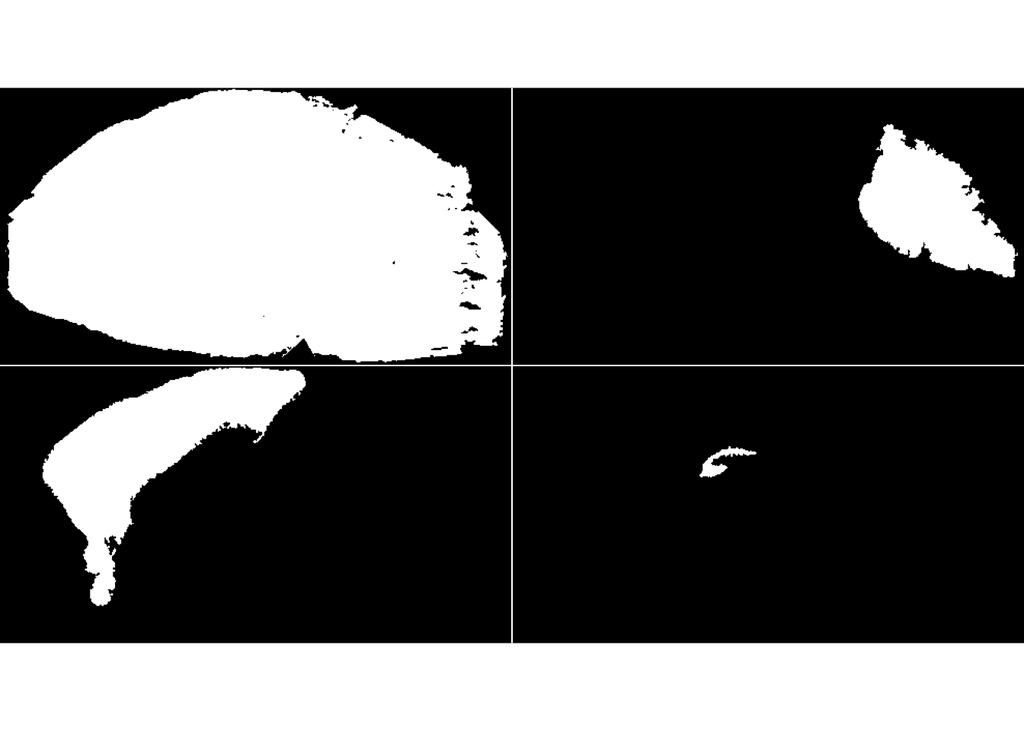

```r
# Function to display images in a 2x2 grid
viewROIs <- function(image_list) {
  # Combine images into a single object
  combined_images <- do.call(combine, image_list)

  # Display the combined images in a 2x2 grid
  display(combined_images, method = "raster", all = TRUE, nx = 2)
}

# Example: Display C5 images
c5_images <- list(
  c5_brain,
  c5_cereb,
  c5_cortex,
  c5_hippo
)

viewROIs(c5_images)
```

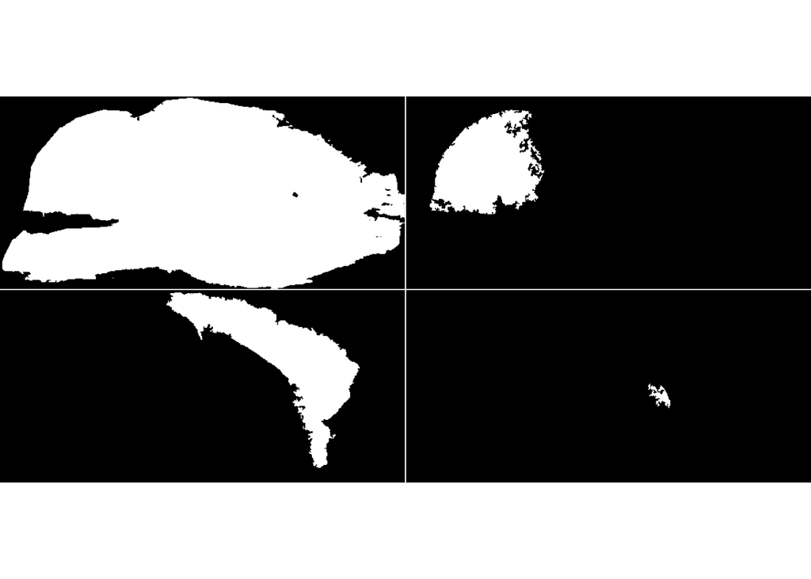

```r
# Example: Display C9 images
c9_images <- list(
  c9_brain,
  c9_cereb,
  c9_cortex,
  c9_hippo
)

viewROIs(c9_images)
```

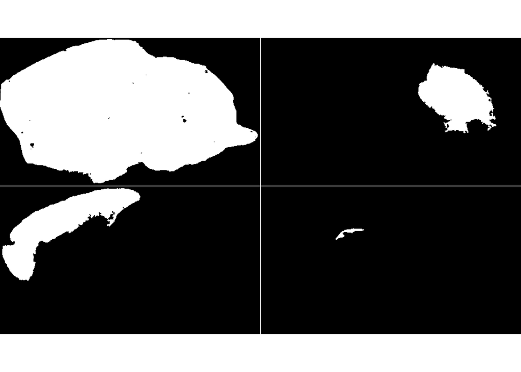

```r
# Example: Display C10 images
c10_images <- list(
  c10_brain,
  c10_cereb,
  c10_cortex,
  c10_hippo
)

viewROIs(c10_images)
```

Since the dimensions of ROIs must match their corresponding processed MSI objects, we use the matchSize function to resize the logical images. This ensures that all ROIs are correctly aligned with their respective datasets.

```r
matchSize <- function(img, target) {

  w <- max(target@elementMetadata$x)
  h <- max(target@elementMetadata$y)

  resized_img <- resize(img, w, h)

  if (is.logical(img)) {
    resized_img <- resized_img > 0
  }

  return(resized_img)
}

c5_cereb <- matchSize(c5_cereb, c5_mse_proc)
c5_cortex <- matchSize(c5_cortex, c5_mse_proc)
c5_hippo <- matchSize(c5_hippo, c5_mse_proc)

c9_cereb <- matchSize(c9_cereb, c9_mse_proc)
c9_cortex <- matchSize(c9_cortex, c9_mse_proc)
c9_hippo <- matchSize(c9_hippo, c9_mse_proc)

c10_cereb <- matchSize(c10_cereb, c10_mse_proc)
c10_cortex <- matchSize(c10_cortex, c10_mse_proc)
c10_hippo <- matchSize(c10_hippo, c10_mse_proc)
```

Once the ROIs are resized, they are reassigned to the MSI objects using the assignROI function, which maps each ROI to its corresponding dataset. This step ensures that subsequent analyses focus only on the selected regions.

```r
# Function to assign ROI to the MSI object
assignROI <- function(msi, roi_list, verbose = FALSE) {
  for (name in names(roi_list)) {
    if (verbose) {
      cat("Assigning ROI:", name, "\n")
    }
    msi[[name]] <- roi_list[[name]]
  }
  return(msi)
}

# Assign ROIs to the MSI objects
c5_rois <- c("c5_cortex", "c5_hippo", "c5_cereb")
c5_roi_list <- mget(c5_rois)
c5_mse_proc <- assignROI(c5_mse_proc, c5_roi_list)

c9_rois <- c("c9_cortex", "c9_hippo", "c9_cereb")
c9_roi_list <- mget(c9_rois)
c9_mse_proc <- assignROI(c9_mse_proc, c9_roi_list)

c10_rois <- c("c10_cortex", "c10_hippo", "c10_cereb")
c10_roi_list <- mget(c10_rois)
c10_mse_proc <- assignROI(c10_mse_proc, c10_roi_list)
```

Next, we extract the Total Ion Count (TIC) for each ROI. The getROITIC function allows us to calculate the TIC, either normalized to the number of pixels in the ROI or as the raw sum. This step helps in understanding the signal intensity distribution across different regions.

```r
# Function to extract TIC for each ROI
getROITIC <- function(msi, roi_list, normalize = TRUE, decimal = 4, verbose = FALSE) {
  df <- NULL
  for (name in names(roi_list)) {
    if (verbose) cat("Get TIC from ROI:", name, "\n")
    tic <- fData(summarizeFeatures(msi, stat="sum", groups=msi[[name]], verbose = FALSE))
    if (is.null(df)) {
      df <- data.frame(mz = as.numeric(format(round(as.matrix(tic[,"mz"]), decimal), nsmall = decimal)))
    }
    if (normalize) {
      new_df <- data.frame(tic = as.matrix(tic[,"TRUE.sum"])/sum(roi_list[[name]]))
    } else {
      new_df <- data.frame(tic = as.matrix(tic[,"TRUE.sum"]))
    }
    colnames(new_df) <- name
    df <- cbind(df, new_df)
  }
  return(df)
}

# Normalized TIC
c5_ndata <- getROITIC(c5_mse_proc, c5_roi_list, normalize = TRUE)
c9_ndata <- getROITIC(c9_mse_proc, c9_roi_list, normalize = TRUE)
c10_ndata <- getROITIC(c10_mse_proc, c10_roi_list, normalize = TRUE)
```

To evaluate the reproducibility of this method and address concerns about variability, we calculate the coefficient of variation (CV) across the ROIs.

```r
# Function to build CV data frame from TIC table
buildCVDataframe <- function(tic_list, col_list, mz_thresh = 1) {
  df <- NULL
  for (name in names(tic_list)) {
    new_df <- tic_list[[name]]
    colnames(new_df) <- c("mz", paste0(col_list, ".", name))
    if (is.null(df)) {
      df <- new_df
    } else {
      df <- merge(df, new_df, all=TRUE)
    }
  }

  # Group data by m/z range (if mz_thresh is not NULL)
  if (!is.null(mz_thresh)) {
    thresh <- 10^-(mz_thresh)
    df[is.na(df)] <- 0
    df$bin <- cut(df$mz, breaks = seq(min(df$mz), max(df$mz), by = thresh), include.lowest = TRUE)
    max_bin <- aggregate(mz ~ bin, data = df, max)
    sum_bin <- aggregate(. ~ bin, data = df[, -1], FUN = sum)
    df <- merge(max_bin, sum_bin)
    df[df == 0] <- NA
    df <- df[order(df$mz),]
    df$bin <- NULL
  }
  return(df)
}

# Function to calculate CV from a CV data frame
getCV <- function(df, roi_list, na.rm = TRUE, outline.rm = TRUE, noise.rm = TRUE, stat = TRUE) {
  result_df <- data.frame(Region = character(), CV = numeric())

  for (roi in roi_list) {
    # Filter columns related to the current ROI
    pattern <- paste0("mz|", roi)
    cv_df <- df[, grepl(pattern, names(df))] |>
      mutate(
        Mean = rowMeans(across(starts_with(roi)), na.rm = TRUE),
        SD = apply(across(starts_with(roi)), 1, sd, na.rm = TRUE),
        CV = SD / Mean *100
      )

    if (na.rm) {
      cv_df <- cv_df[complete.cases(cv_df), ]
    }

    if (noise.rm) {
      # Calculate signal-to-noise ratio (assuming noise is the SD)
      cv_df$SNR <- cv_df$Mean / cv_df$SD
      cv_df <- cv_df[cv_df$SNR >= 3, ]
    }

    if (outline.rm) {
      Q1 <- quantile(cv_df$CV, 0.25, na.rm = TRUE)
      Q3 <- quantile(cv_df$CV, 0.75, na.rm = TRUE)
      IQR <- Q3 - Q1
      lower_bound <- Q1 - 1.5 * IQR
      upper_bound <- Q3 + 1.5 * IQR
      cv_df <- cv_df[cv_df$CV >= lower_bound & cv_df$CV <= upper_bound, ]
    }

    # Compute average mean, SD and CV for the current ROI
    mean_mean <- mean(cv_df$Mean, na.rm = TRUE)
    mean_sd <- sd(cv_df$SD, na.rm = TRUE)
    mean_cv <- mean(cv_df$CV, na.rm = TRUE)

    if (stat) {
      new_df <- data.frame(Region = roi, Mean = mean_mean, SD = mean_sd,  CV = mean_cv)
    } else {
      new_df <- data.frame(Region = roi, CV = mean_cv)
    }

    result_df <- rbind(result_df, new_df)
  }

  return(result_df)
}

tic_list <- mget(c("c5_ndata", "c9_ndata", "c10_ndata"))
col_list <- c("Cortex", "Hippocampus", "Cerebellum")
cv_df <- buildCVDataframe(tic_list, col_list)
cv <- getCV(cv_df, col_list, na.rm = TRUE, outline.rm = TRUE, noise.rm = TRUE)

# View CV values
cv
```

```
##        Region     Mean        SD       CV
## 1      Cortex 338.3969 122.46164 22.30915
## 2 Hippocampus 428.9770 189.17335 21.15137
## 3  Cerebellum 313.9900  65.34667 18.12568
```

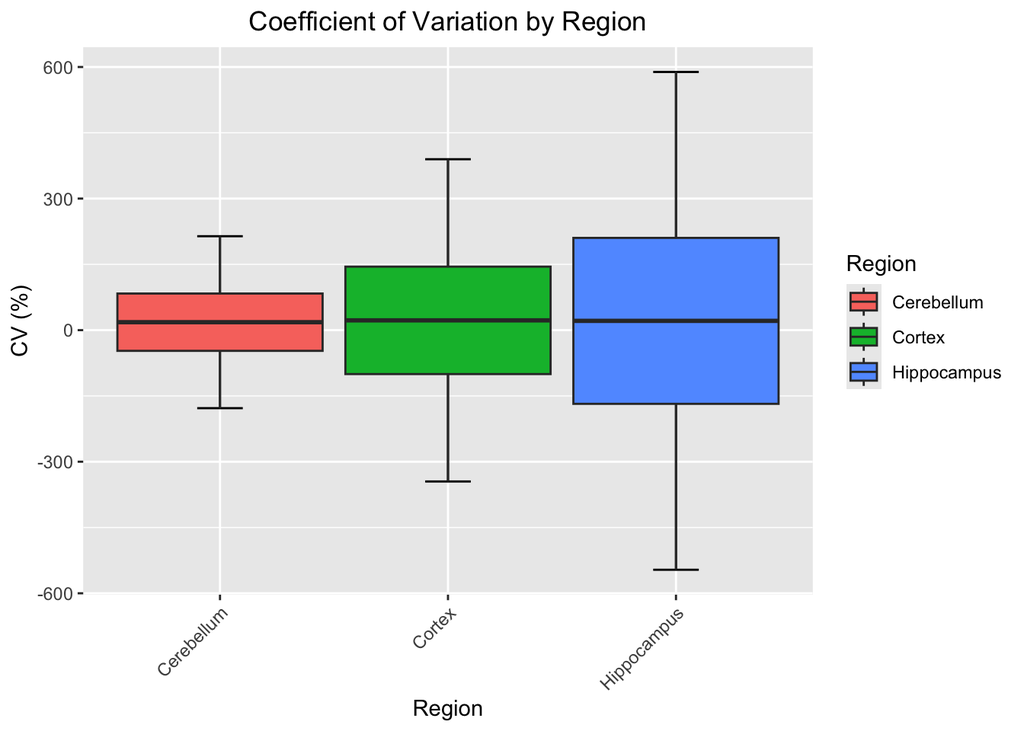

```r
p <- ggplot(cv, aes(x = Region, y = CV, fill = Region)) +
  geom_errorbar(aes(ymin = CV - 3*SD, ymax = CV + 3*SD), width = 0.2) +
  geom_boxplot(aes(lower=CV-SD, upper=CV+SD, middle=CV, ymin=CV-3*SD, ymax=CV+3*SD),
               stat = "identity",) +
  labs(title = "Coefficient of Variation by Region",
       x = "Region",
       y = "CV (%)") +
  theme(axis.text.x = element_text(angle = 45, hjust = 1),
        plot.title = element_text(hjust = 0.5))

print(p)
```

```r
# Function to extract target compounds from TIC table
filterMetaboliteTIC <- function(msi_df, ion_list, tracing=NULL) {
  msi_tic <- list()
  if (is.data.frame(ion_list)) {
    metabolite_names <- ion_list[, unlist(lapply(ion_list, is.character), use.names = FALSE)]
    mass_list <- ion_list[, unlist(lapply(ion_list, is.numeric), use.names = FALSE)]
    if (!is.null(tracing)) {
      new_names <- NULL
      new_masses <- NULL
      new_df <- NULL
      for (i in tracing) {
        new_names <- c(new_names, paste0(metabolite_names,"_M",i))
        new_masses <- c(new_masses, mass_list + (i*1.00783))
      }
      new_df <- data.frame(Metabolite=new_names, mz=new_masses)
      new_df[order(new_df$Metabolite),]
      metabolite_names <- new_df$Metabolite
      mass_list <- new_df$mz
    }

    head_col <- data.frame(Metabolite=metabolite_names, mz=mass_list)
  } else {
    mass_list <- ion_list
    head_col <- data.frame(mz=mass_list)
  }

  for (i in seq_along(mass_list)) {
    mass <- mass_list[i]
    row_number <- which.min(abs(msi_df$mz - mass))
    col_number <- which(colnames(msi_df)=="mz") + 1
    new_tic <- cbind(head_col[i, , drop=FALSE], msi_df[row_number, col_number:ncol(msi_df)])
    msi_tic <- rbind(msi_tic, new_tic)
  }

  return(msi_tic)
}

# Define isotopologue data
tic_list <- mget(c("c5_ndata", "c9_ndata", "c10_ndata"))
col_list <- c("Cortex", "Cerebellum")
gaba_isotopologue <- data.frame(
  Metabolite = c("GABA_M0", "GABA_M1", "GABA_M2", "GABA_M3",  "GABA_M4"),
  Mass = c(104.07095,   105.07434,  106.07773,  107.08112,  108.08451)
)
gln_isotopologue <- data.frame(
  Metabolite = c("Glutamine_M0", "Glutamine_M1", "Glutamine_M2", "Glutamine_M3",  "Glutamine_M4", "Glutamine_M5"),
  Mass = c(147.07694,   148.060065, 149.08319,  150.072315, 151.06944,  152.042565)
)
glu_isotopologue <- data.frame(
  Metabolite = c("Glutamate_M0", "Glutamate_M1", "Glutamate_M2", "Glutamate_M3",  "Glutamate_M4", "Glutamate_M5"),
  Mass = c(148.06102,   149.06433,  150.06764,  151.07095,  152.07426,  153.07757)
)
six_metabolites <- NULL
six_metabolites <- rbind(gaba_isotopologue, gln_isotopologue, glu_isotopologue)

# Extract metabolites for each dataset
c5_6mets <- filterMetaboliteTIC(c5_ndata, six_metabolites)
c9_6mets <- filterMetaboliteTIC(c9_ndata, six_metabolites)
c10_6mets <- filterMetaboliteTIC(c10_ndata, six_metabolites)

# Merge the extracted data into a single data frame
final_data <- merge(merge(c5_6mets, c9_6mets), c10_6mets)
```

To account for natural isotope abundances and tracer enrichment effects, we use the IsocorrectoR package. This step prepares input files (measurement, molecule, and element) necessary for isotope correction. The prepIsocoR function formats the data for IsocorrectoR by renaming columns and rows in the measurement file, defining the isotopologue structure in the molecule file, and specifying isotope abundances and tracer properties in the element file. These files are then used with the IsoCorrection function to generate corrected data. The corrected results are saved in a specified output directory for downstream analysis.

```r
# Function to prepare and correct natural abundance using IsocorrectoR
prepIsocoR <- function(measure_file = NA, molecule_file = NA, element_file = NA, outdir = ".") {
  # check input
  if (is.null(measure_file) || !is.data.frame(measure_file)) {
    stop("Please provide a valid data frame for the measurement file.")
  }

  # Rename column name
  colnames(measure_file)[-1] <- paste0("Sample", seq_along(colnames(measure_file)[-1]))
  colnames(measure_file)[1] <- "Measurements/Samples"

  # Rename row name
  measure_file$`Measurements/Samples` <- gsub("M", "", measure_file$`Measurements/Samples`)
  rownames(measure_file) <- NULL

  measure_file_path <- file.path(outdir, "measure_file.csv")
  write.csv(measure_file, file = measure_file_path, row.names = FALSE)

  metabolites <- c("GABA", "Glutamate", "Glutamine")
  formulas <- c("C4H9N1O2LabC4", "C5H9N1O4LabC5", "C5H10N2O3LabC5")
  neutral_loss <- c(NA, NA, NA)

  molecule_file <- data.frame(
    Molecule = metabolites,
    `MS ion or MS/MS product ion` = formulas,
    `MS/MS neutral loss` = neutral_loss
  )

  colnames(molecule_file) <- c(
    "Molecule",
    "MS ion or MS/MS product ion",
    "MS/MS neutral loss"
  )

  write.csv(molecule_file, file = "molecule_file.csv", row.names = FALSE)

  # Create a data frame for the element file
  element_file <- data.frame(
    Element = c("C", "H", "N", "O"),
    `Isotope abundance_Mass shift` = c(
      "0.0107_1/0.9893_0",  # Carbon isotopes
      "0.000115_1/0.999885_0",  # Hydrogen isotopes
      "0.99632_0/0.00368_1",  # Nitrogen isotopes
      "0.99757_0/0.00038_1/0.00205_2"  # Oxygen isotopes
    ),
    `Tracer isotope mass shift` = c(1, 1, 1, 2),
    `Tracer purity` = c(0.99, 0.99, 0.99, 0.99)
  )

  colnames(element_file) <- c(
    "Element",
    "Isotope abundance_Mass shift",
    "Tracer isotope mass shift",
    "Tracer purity"
  )

  write.csv(element_file, file = "element_file.csv", row.names = FALSE)

  invisible(NULL)
}

prepIsocoR(measure_file = final_data)

IsoCorrection(
    MeasurementFile = "measure_file.csv",
    MoleculeFile = "molecule_file.csv",
    ElementFile = "element_file.csv",
    DirOut = "../../Results/4EF",                       # Output directory
    FileOut = "final_data",         # Output file name
    FileOutFormat = "csv",              # Output file format
    CorrectTracerImpurity = TRUE,
    CorrectTracerElementCore = TRUE,
    CalculateMeanEnrichment = TRUE
)
```

```
##
## ################################################################################
```

```
## Wed Jan 22 12:18:00 2025 :: Starting IsoCorrection ...
```

```
##
##
##
## Wed Jan 22 12:18:01 2025 :: IsoCorrection successfully completed!
##
## ################################################################################
```

[output not shown]

[output cut: 227 more lines]

[output not shown]

After correcting the natural abundance using the IsoCorrectoR package, we rename the output for traceability. From the corrected results, we prepare a heatmap and bar plot to visualize the distribution and enrichment of metabolites across tissues.

```r
# Read  and process result

corrected_final_data <- read.csv("../../Results/4EF/Isocorrected_results/IsoCorrectoR_final_data_Corrected.csv")
corrected_final_data$X <- gsub("_(\\d+)$", "_M\\1", corrected_final_data$X)
names(corrected_final_data) <- names(final_data)

#Create a dataframe to make the data suitable for plotting:
final_data_2 <- corrected_final_data %>%
  separate(Metabolite, into = c("Metabolite_1", "Ion"), sep = "_") %>%
  pivot_longer(
    cols = starts_with("c"), # Seleccionar las columnas que empiezan con "c"
    names_to = "Tissue",     # Nombre de la nueva columna con las variables originales
    values_to = "Values"     # Nombre de la columna con los valores
  ) %>%
  group_by(Metabolite_1, Tissue) %>%
  mutate(
    Total = sum(Values, na.rm = TRUE),       # Calcular la suma total de los valores por Metabolite_1 y Tissue
    Normalized_Value = Values / Total       # Dividir cada valor por el total
  ) %>%
  ungroup() %>%
  select(-Total) %>%
  mutate(
    Tissue_Group = case_when(
      str_ends(Tissue, "cortex") ~ "Cortex",  # Identificar tejidos que terminan en "cortex"
      str_ends(Tissue, "hippo") ~ "Hippo",    # Identificar tejidos que terminan en "hippo"
      str_ends(Tissue, "cereb") ~ "Cereb"     # Identificar tejidos que terminan en "cereb"
    )
  ) %>%
  group_by(Metabolite_1, Tissue_Group, Ion) %>%
  summarize(
    Avg_Normalized_Value = mean(Normalized_Value, na.rm = TRUE),  # Calcular el promedio
    StdDev_Normalized_Value = sd(Normalized_Value, na.rm = TRUE), # Calcular la desviación estándar
    .groups = "drop"  # Desagrupar después de calcular
  ) %>%
  ungroup() %>%
  unite("Metabolite", Metabolite_1, Ion, sep = "_")  # Unir las columnas Metabolite_1 e Ion

# Specify the desired metabolite order (reversed for Pyruvate to appear at the top):
desired_order <- rev(c(
  "Pyruvate_M0", "Pyruvate_M1", "Pyruvate_M2", "Pyruvate_M3",
  "Glutamate_M0", "Glutamate_M1", "Glutamate_M2", "Glutamate_M3", "Glutamate_M4", "Glutamate_M5",
  "Glutamine_M0", "Glutamine_M1", "Glutamine_M2", "Glutamine_M3", "Glutamine_M4", "Glutamine_M5",
  "GABA_M0", "GABA_M1", "GABA_M2", "GABA_M3", "GABA_M4",
  "Succinate_M0", "Succinate_M1", "Succinate_M2", "Succinate_M3", "Succinate_M4",
  "Fumarate_M0", "Fumarate_M1", "Fumarate_M2", "Fumarate_M3", "Fumarate_M4"
))

# Update the Metabolite column to follow the reversed desired order
final_data_2 <- final_data_2 %>%
  mutate(Metabolite = factor(Metabolite, levels = desired_order))

# Generate the ggplot heatmap with reversed y-axis for Figure 4E
final_data_2_heatmap <- final_data_2 %>%
  ggplot(aes(x = Tissue_Group, y = Metabolite, fill = Avg_Normalized_Value)) +
  geom_tile(color = "grey") +  # Add borders for better readability
  scale_fill_gradient2(
    low = "blue", mid = "white", high = "red", midpoint = 0.3,  # Set midpoint to 0.3
    na.value = "grey"  # Set color for NA values
  ) +
  labs(
    x = "Tissue Group",
    y = "Metabolite",
    fill = "Avg Normalized Value"
  ) +
  theme_minimal() +
  theme(
    axis.text.x = element_text(angle = 45, hjust = 1),  # Rotate x-axis text for readability
    axis.text.y = element_text(size = 8),              # Adjust y-axis text size
    panel.grid.major = element_blank(),                # Remove grid lines
    panel.grid.minor = element_blank()
  )
ggsave(final_data_2_heatmap, filename = "../../Results/4EF/final_data_heatmap.pdf", height = 7, width = 4)


#Barplot with Glutamate, Glutamine, and GABA for Figure 4F
final_data_2_barplot <- final_data_2 %>%
  separate(Metabolite, into = c("Metabolite_1", "Ion"), sep = "_") %>%
  filter(Metabolite_1 %in% c("Glutamate", "Glutamine", "GABA", "Fumarate"),
         Ion %in% c("M0", "M2"),
         Tissue_Group %in% c("Cereb", "Cortex")) %>%
  mutate(Metabolite_1 = factor(Metabolite_1, levels = c("Glutamate", "Glutamine", "GABA", "Fumarate"))) %>%  # Set facet order
  ggplot(aes(x = Tissue_Group, y = Avg_Normalized_Value, fill = Ion)) +
  geom_errorbar(aes(ymin = Avg_Normalized_Value - StdDev_Normalized_Value,
                    ymax = Avg_Normalized_Value + StdDev_Normalized_Value, color = Ion),
                position = position_dodge(width = 1), width = 0.2) +  # Error bars
  geom_bar(stat = "identity", position = position_dodge(width = 1)) +  # Bar plot with dodge for grouping
  facet_wrap(~ Metabolite_1, scales = "free_y") +  # Facet by metabolite
  scale_color_manual(values = c("dodgerblue1", "red")) +  # Color error bars
  scale_fill_manual(values = c("dodgerblue1", "red")) +  # Color bars
  labs(
    x = "Brain Region",
    y = "Avg Normalized Value",
    fill = "Isotopologue"
  ) +
  scale_y_continuous(name = "C-13 Enrichment", expand = c(0, 0), breaks = seq(0, 1.2, 0.2)) +
  theme(
    axis.title.y = element_text(color = "black"),
    axis.title.y.right = element_text(color = "blue"),
    axis.text = element_text(size = 12, color = "black", family = "Helvetica"),
    axis.title = element_text(size = 12, face = "bold", color = "black"),
    axis.text.x = element_text(angle = 0, hjust = 0.5, vjust = 1.2, color = "black")
  ) +
  coord_cartesian(ylim = c(0, 1))


ggsave(final_data_2_barplot, filename = "../../Results/4EF/final_data_barplot.pdf", height = 6, width = 6)
```